### Luca Fregona

# INVESTIRE IN UN AIRBNB:

# **VENEZIA**

#### Progetto Data Science

## **MOTIVAZIONI:**

Il mondo degli affitti brevi e nella fattispecie di AirBnB mi ha sempre incuriosito e con l'occasione ho voluto capire se c'è la possibilità di fare uno studio da proporre a dei possibili investitori

## **OBBIETTIVI POSTI**

1. Comprendere in modo descrittivo i dati più rilevanti nel mondo degli AirBnB a Venezia
2. individuare in modo oggettivo una zona più favorevole per un eventuale investimento e capire cosa influenza il prezzo in un AirBnb

## **DESCRIZIONE DEL DATAFRAME**

Il download del dataframe è disponibile su Inside AirBnB oppure al seguente link: [Download](https://data.insideairbnb.com/italy/veneto/venice/2024-03-10/data/listings.csv.gz)

#### Per preparare il dataframe alla visualizzazione ho:

- Selezionato solamente le colonne rilevanti per l'analisi
- Escluso tutte le entry corrispondenti alla zona "Terraferma" di Venezia
- Droppato le righe con valori NaN nelle categorie più rilevanti (es. 'Price')
- Riempito le righe con valori NaN con informazioni opportune nelle altre colonne
- Dove necessario ho sistemato i Dtype attraverso dei casting

```
<class 'pandas.core.frame.DataFrame'>
Index: 5347 entries, 0 to 7999
Data columns (total 20 columns):
 #   Column                        Non-Null Count  Dtype
---  ------                        --------------  -----
 0   id                            5347 non-null   int64
 1   name                          5347 non-null   object
 2   description                   5347 non-null   object
 3   host_name                     5347 non-null   object
 4   host_since                    5347 non-null   datetime64[ns]
 5   host_is_superhost             5347 non-null   object
 6   host_total_listings_count     5347 non-null   int64
 7   neighbourhood_cleansed        5347 non-null   object
 8   neighbourhood_group_cleansed  5347 non-null   object
 9   latitude                      5347 non-null   float64
 10  longitude                     5347 non-null   float64
 11  room_type                     5347 non-null   object
 12  accommodates                  5347 non-null   int64
 13  bathrooms                     5347 non-null   float64
 14  bedrooms                      5347 non-null   float64
 15  amenities                     5347 non-null   object
 16  price                         5347 non-null   float64
 17  number_of_reviews             5347 non-null   int64
 18  review_scores_rating          5347 non-null   float64
 19  quote_count                   5347 non-null   int64
dtypes: datetime64[ns](1), float64(6), int64(5), object(8)
memory usage: 877.2+ KB
```

## Parte 1:

### Comprendere in modo descrittivo i dati più rilevanti nel mondo degli AirBnB a Venezia

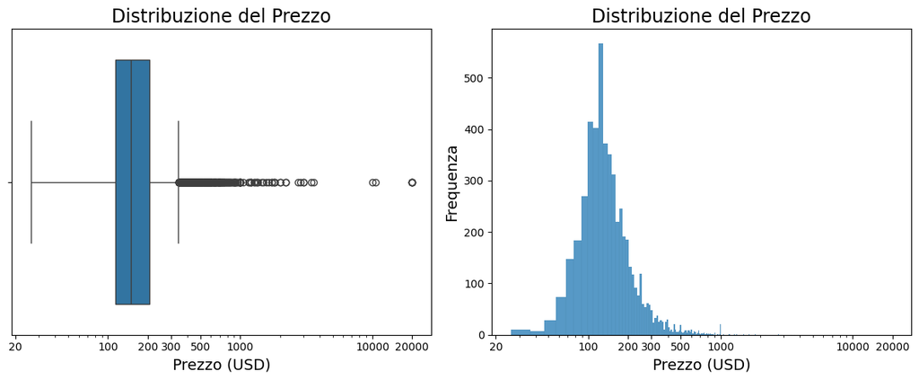

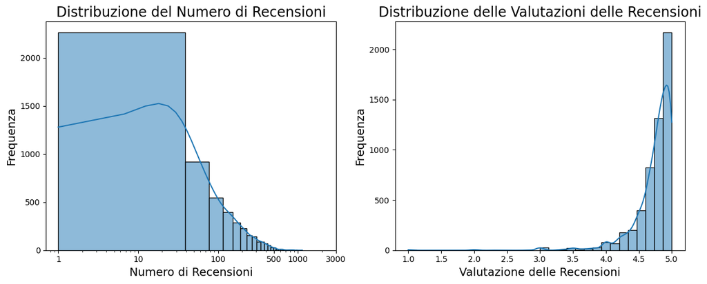

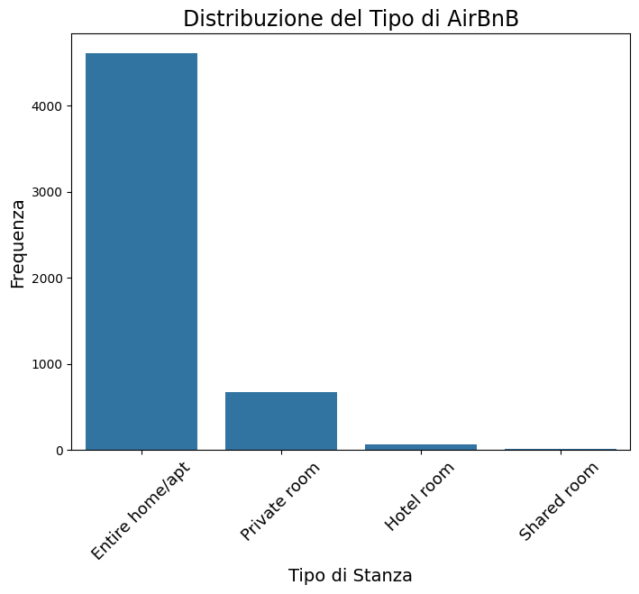

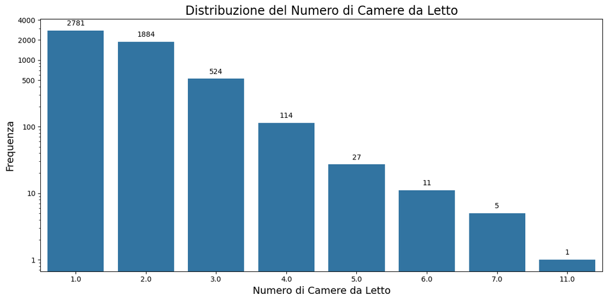

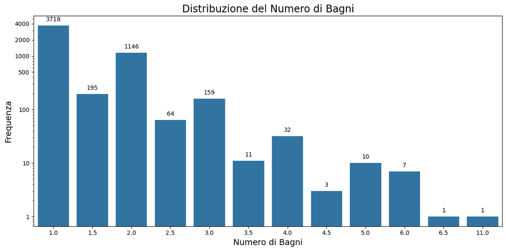

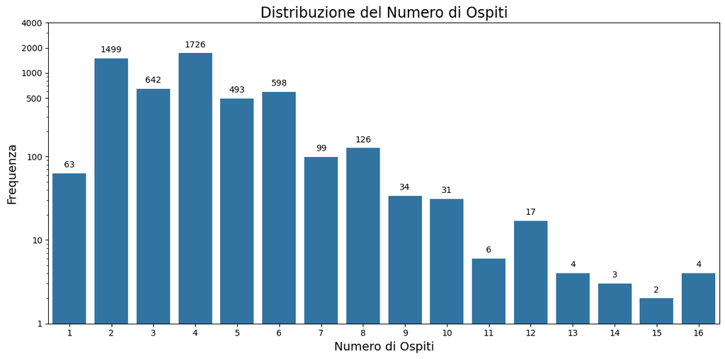

## Parte 2:

### E' possibile individuare in modo oggettivo una zona più favorevole per un eventuale investimento e capire cosa influenza il prezzo in un AirBnb?

|  | Quartiere | Prezzo | Numero Alloggi |
| --- | --- | --- | --- |
| 15 | San Polo | 215.015656 | 511 |
| 16 | Lido | 222.912548 | 263 |
| 17 | San Marco | 243.089263 | 773 |
| 18 | Torcello | 250.000000 | 1 |
| 19 | Castello | 262.179706 | 1291 |

```
L'indice di Pearson tra prezzo e numero di alloggi corrisponde a: 0.586367
```

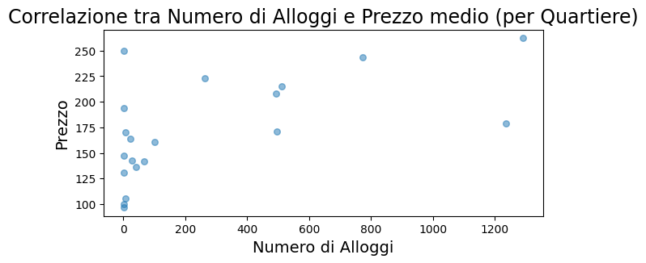

|  | Quartiere | Valutazione delle Recensioni | Numero Alloggi | Prezzo |
| --- | --- | --- | --- | --- |
| 0 | Tronchetto | 4.000000 | 1 | 194.000000 |
| 1 | Pellestrina | 4.410000 | 3 | 96.666667 |
| 2 | Alberoni | 4.418148 | 27 | 142.888889 |
| 3 | Sant'Erasmo | 4.523750 | 8 | 105.750000 |
| 4 | Cannaregio | 4.715958 | 1237 | 179.051738 |

L'indice di Pearson tra Valutazione delle Recensioni e Prezzo corrisponde a: 0.086976

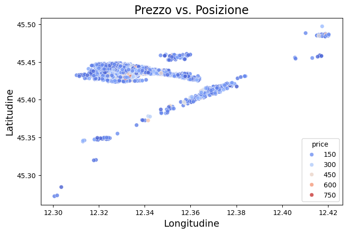

[interactive chart not shown]

|  | Numero Ospiti | price |
| --- | --- | --- |
| 0 | 1 | 88.444444 |
| 1 | 2 | 158.374249 |
| 2 | 3 | 197.933022 |
| 3 | 4 | 209.373696 |
| 4 | 5 | 248.697769 |
| 5 | 6 | 260.217391 |
| 6 | 7 | 295.262626 |
| 7 | 8 | 376.269841 |
| 8 | 13 | 390.750000 |
| 9 | 11 | 403.333333 |
| 10 | 10 | 498.548387 |
| 11 | 9 | 524.823529 |
| 12 | 12 | 532.705882 |
| 13 | 14 | 1081.333333 |
| 14 | 16 | 1371.250000 |
| 15 | 15 | 2200.000000 |

```
L'indice di Pearson tra prezzo medio e numero di ospiti corrisponde a: 0.76562
```

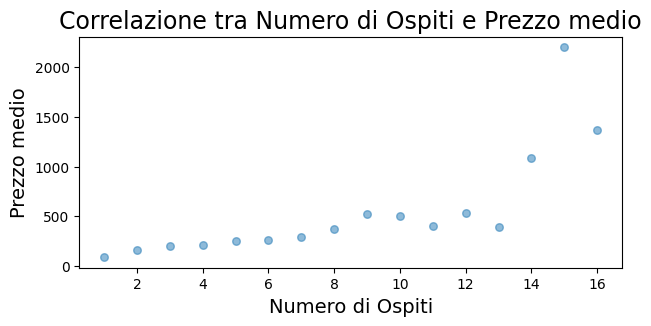

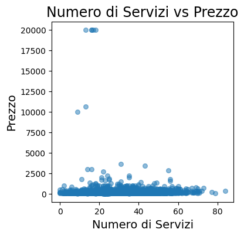

## Conclusioni

- Non è stato possibile per me, con questi dati, individuare in modo oggettivo una zona più favorevole rispetto ad altre per una eventuale proposta di investimento
- Ho riscontrato diverse difficoltà nel trovare abbastanza correlazioni che possano dare risultati interessanti per comprendere cosa influenza il prezzo in un AirBnB

*L'analisi ha portato a qualche risultato ma non particolarmente interessante da presentarla a dei possibili investitori*